# Assignment: Course Project 1

Juan M Garcia-Gomez

6 de febrero de 2016

## Loading and preprocessing the data

```r
activityData <- read.csv("activity.csv",colClasses=c("numeric", "Date", "integer"))
```

## What is mean total number of steps taken per day?

For this part of the assignment, you can ignore the missing values in the dataset.

### 1. Calculate the total number of steps taken per day

```r
sumStepsByDay <- aggregate(activityData[,1], list(activityData$date), sum)
colnames(sumStepsByDay) <- c("date","sumSteps")
```

### 2. If you do not understand the difference between a histogram and a barplot, research the difference between them. Make a histogram of the total number of steps taken each day

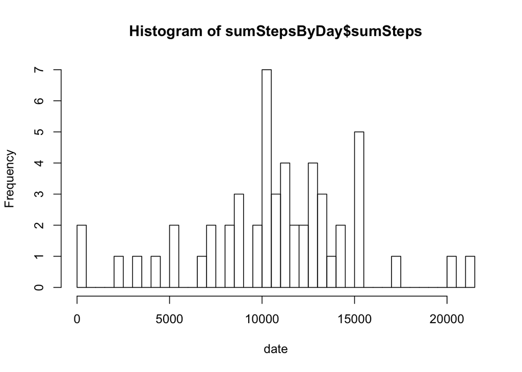

```r
hist(sumStepsByDay$sumSteps,xlab="date",labels=sumStepsByDay[1],breaks=61)
```

### 3. Calculate and report the mean and median of the total number of steps taken per day

```r
meanStepsByDay <- aggregate(activityData[,1], list(activityData$date), mean)
colnames(meanStepsByDay) <- c("date","meanSteps")
medianStepsByDay <- aggregate(activityData[,1], list(activityData$date), median)
colnames(medianStepsByDay) <- c("date","medianSteps")
```

[output not shown]

## What is the average daily activity pattern?

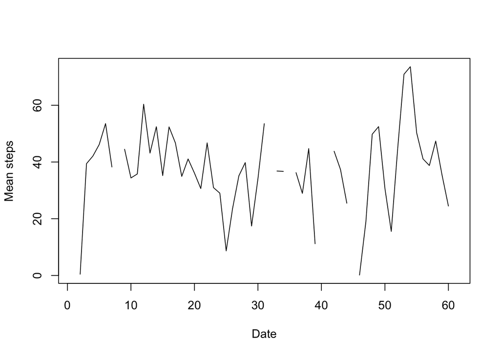

```r
plot(1:length(meanStepsByDay[,1]),meanStepsByDay$meanSteps,type="l",xlab="Date",ylab="Mean steps")
```

```r
which.max(meanStepsByDay$meanSteps)
```

```
## [1] 54
```

## Imputing missing values

### 1. Calculate and report the total number of missing values in the dataset (i.e. the total number of rows with NAs

```r
sum(is.na(activityData$steps))
```

```
## [1] 2304
```

### 2. Devise a strategy for filling in all of the missing values in the dataset. The strategy does not need to be sophisticated. For example, you could use the mean/median for that day, or the mean for that 5-minute interval, etc.

```r
inputationValue <- mean(meanStepsByDay[,"meanSteps"], na.rm=T)
```

### 3. Create a new dataset that is equal to the original dataset but with the missing data filled in.

```r
activityDataNoNA <- activityData
activityDataNoNA[is.na(activityDataNoNA$steps),"steps"] <- inputationValue
```

### 4. Make a histogram of the total number of steps taken each day and Calculate and report the mean and median total number of steps taken per day.

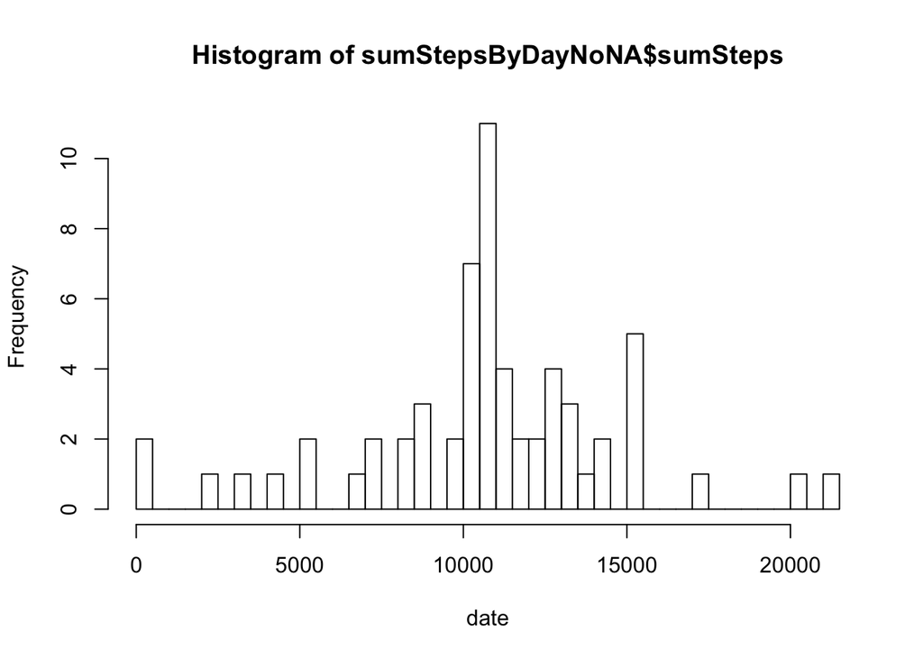

```r
sumStepsByDayNoNA <- aggregate(activityDataNoNA[,1], list(activityDataNoNA$date), sum)
colnames(sumStepsByDayNoNA) <- c("date","sumSteps")
hist(sumStepsByDayNoNA$sumSteps,xlab="date",labels=sumStepsByDayNoNA[1],breaks=61)
```

- Do these values differ from the estimates from the first part of the assignment?

Yes, there were 8 in first part, whereas there are 0 after missing data were filled.

## Are there differences in activity patterns between weekdays and weekends?

### 1. Create a new factor variable in the dataset with two levels - weekday and weekend indicating whether a given date is a weekday or weekend day.

```r
activityDataNoNA$weekdays <- weekdays(activityDataNoNA$date)
activityDataNoNA$weeks[activityDataNoNA$weekdays == "sábado" | activityDataNoNA$weekdays == "Saturday" | activityDataNoNA$weekdays == "domingo" |activityDataNoNA$weekdays == "Sunday"] <- "weekend"
activityDataNoNA$weeks[!(activityDataNoNA$weekdays == "sábado" | activityDataNoNA$weekdays == "Saturday" | activityDataNoNA$weekdays == "domingo" |activityDataNoNA$weekdays == "Sunday")] <- "weekday"
```

*Spanish characters requires the UTF-8 format, I hope this works in other countries*

### 2. Make a panel plot containing a time series plot of the 5-minute interval (x-axis) and the average number of steps taken, averaged across all weekday days or weekend days (y-axis). See the README file in the GitHub repository to see an example of what this plot should look like using simulated data.

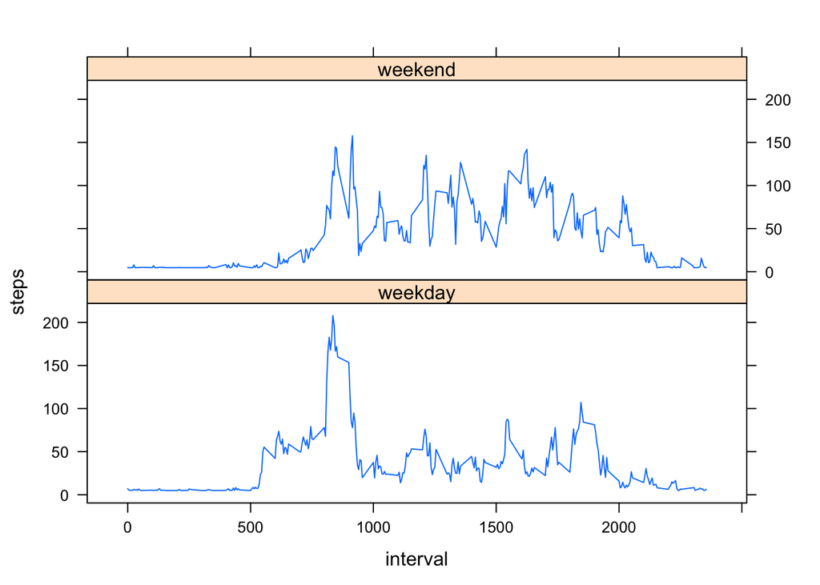

```r
library(plyr)
activityDataWeeks <- ddply(activityDataNoNA, c("interval", "weeks"), function(x) apply(x[1],2,mean))

library(lattice)
xyplot(steps ~ interval | weeks, data = activityDataWeeks, type = "l", xlab = "interval", ylab = "steps", layout = c(1, 2))
```